# Sports Analytics Project

Ian Keller

2023-10-19

Reading in Each CSV

```r
advanced_stats = read.csv('Player Season Totals - 2022-23 Advanced Stats.csv')

basic_stats = read.csv('Player Season Totals - 2022-23 Basic Stats.csv')

player_bio = read.csv('Player Season Totals - 2022-23 Player Bios.csv')
```

Merging Data Sets Based on Name

```r
#Combining the player bio and basic stats data sets
combined_data <- merge(player_bio, basic_stats, by = "Player")

#Combining the advanced stats with the previously merged data
combined_data2 <- merge(advanced_stats, combined_data, by = "Player")
```

Adding in the salary dataset

```r
player_salary = read.csv("2022-2023 Player Salaries.csv")
#Indexing only the player name and salary columns
player_and_salary <- player_salary[, c("Name", "AAV")]

#Renaming the "Name" Column to "Player" for a proper merge
library("dplyr")
player_and_salary <- player_and_salary %>%
  rename(Player = Name)

#Renaming the player columns to match case sensitivity
combined_data2$Player <- tolower(combined_data2$Player)
player_and_salary$Player <- tolower(player_and_salary$Player)

#Finally merging all the data into the final dataset
final_data <- merge(combined_data2, player_and_salary, by = "Player")
```

Next, I will have to clean the data. Remove irrelevant and duplicate columns as we move closer towards analysis. -For starters, I want to remove some count variables like Corsi For and Corsi Against and leave Corsi %

```r
library(dplyr)
cleaned_data <- final_data %>% select(-CF,-CA,-FF,-FA,-SF,-SA,-GF,-GA,-xGF,-xGA,-SCF,-SCA,-HDCF,-HDCA,-HDGF,-HDGA, -MDCF,-MDCA,-MDGF,-MDGA,-LDCF,-LDCA,-LDGF,-LDGA,-Off..Zone.Starts,-Neu..Zone.Starts,-Def..Zone.Starts,-On.The.Fly.Starts,-Off..Zone.Faceoffs,-Neu..Zone.Faceoffs,-Def..Zone.Faceoffs,-X.x,-Team.x,-Position.x,-Birth.Country,-Birth.City,-Date.of.Birth,-Draft.Team,-Round.Pick,-X.y,-Team.y,-Position.y,-GP.y,-X,-Faceoffs.Won,-Faceoffs.Lost,-Hits.Taken,-iCF,-iFF,-iSCF,-iHDCF,-SH.,-ixG,-Total.Penalties,-Minor,-Major,-Misconduct,-FF,-TOI.y,-Team, -On.Ice.SH.,-On.Ice.SV.,-HDCF.,-Nationality,-Birth.State.Province)
```

I now want to convert some count statistics to rate variables. Additionally, I want to create a variable called “Years_since_draft” as I believe the longer they have been in the league can correlate to higher salaries. I expect this variable to be normally distributed as well, meaning that the middle of the career is the highest with two tails at a young and old age.

```r
library(dplyr)

#Converting Draft.Year collumn to a numeric value
cleaned_data$Draft.Year <- as.numeric(cleaned_data$Draft.Year)
cleaned_data2 <- cleaned_data %>%
  mutate(
    GPG = Goals / GP.x,
    TOIpg = TOI.x / GP.x,
    AsPG = Total.Assists / GP.x,
    Primary_AsPG = First.Assists / GP.x,
    Secondary_AsPG = Second.Assists / GP.x,
    Years_since_draft = abs(Draft.Year - 2022),
    PPG = Total.Points / GP.x)
```

Testing if there are any duplicate names

```r
library(dplyr)

non_unique_players <- cleaned_data2 %>%
  group_by(Player) %>%
  filter(n() > 1) %>%
  arrange(Player)

print(unique(non_unique_players$Player))
```

```
## [1] "sebastian aho"
```

There were 16 duplicate sebastian aho rows, but only two players in the league with that name. This will filter it out to show the two proper rows.

```r
library(dplyr)

non_unique_players <- non_unique_players[c(3, 14), ]
```

Merging the two datasets

```r
other_players_data <- cleaned_data2 %>%
  filter(Player != "sebastian aho")

# Combine the two datasets
all_data_filtered <- bind_rows(non_unique_players, other_players_data)
```

Removing all NA values for salary and renaming AAV to Salary

```r
all_data_filtered <- na.omit(all_data_filtered, cols = "AAV")
#Renaming AAV
all_data_filtered <- all_data_filtered %>%
  rename(Salary = AAV)
```

Furthermore, I need to transform Salary from a string to an integer

```r
library(readr)

all_data_filtered$Salary <- parse_number(all_data_filtered$Salary)
```

Multiplying Salary by 1,000,000

```r
all_data_filtered$Salary <- all_data_filtered$Salary * 1000000
```

Removing salaries of 0

```r
library(dplyr)

all_data_filtered <- all_data_filtered %>%
  filter(Salary != 0 & GP.x >= 41)
```

Looking at some descriptive statistics. First let’s inspect the dependent variable of salary (AAV).

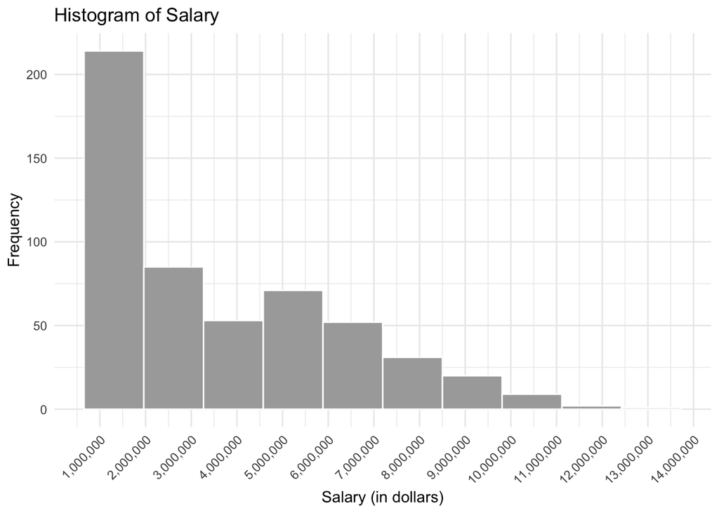

```r
library(ggplot2)
library(scales)
ggplot(all_data_filtered, aes(x = Salary)) +
  geom_histogram(bins = 10, fill = "darkgrey", color = "white") +
  theme_minimal() +
  scale_x_continuous(labels = scales::comma, breaks = scales::pretty_breaks(n = 12)) +
  labs(title = "Histogram of Salary", x = "Salary (in dollars)", y = "Frequency") +
  theme(axis.text.x = element_text(angle = 45, vjust = 1, hjust=1))
```

Performing a log transformation

```r
all_data_filtered$Log_salary <- log(all_data_filtered$Salary)
```

Histogram of Log Salaries

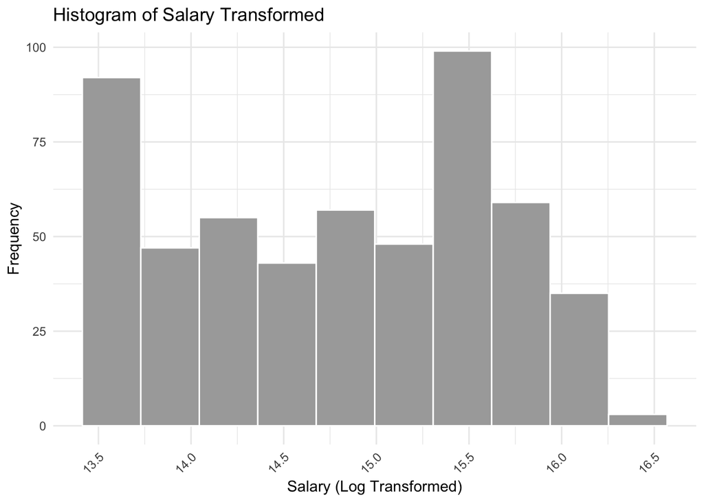

```r
library(ggplot2)
library(scales)

ggplot(all_data_filtered, aes(x = Log_salary)) +
  geom_histogram(bins = 10, fill = "darkgrey", color = "white") +
  theme_minimal() +
  scale_x_continuous(labels = scales::comma, breaks = scales::pretty_breaks(n = 12)) +
  labs(title = "Histogram of Salary Transformed", x = "Salary (Log Transformed)", y = "Frequency") +
  theme(axis.text.x = element_text(angle = 45, vjust = 1, hjust=1))
```

5 number summary

```r
# Calculate the 5-number summary for the Salary variable
five_num_summary <- summary(all_data_filtered$Salary)
print(five_num_summary)
```

```
##     Min.  1st Qu.   Median     Mean  3rd Qu.     Max.
##   730000  1200000  2975000  3602565  5500000 12500000
```

Creating a binary column for Offense vs Defense

```r
all_data_filtered$Offense_defense <- ifelse(all_data_filtered$Position == "D",1,0)
```

Plotting Points Per Game against Salary

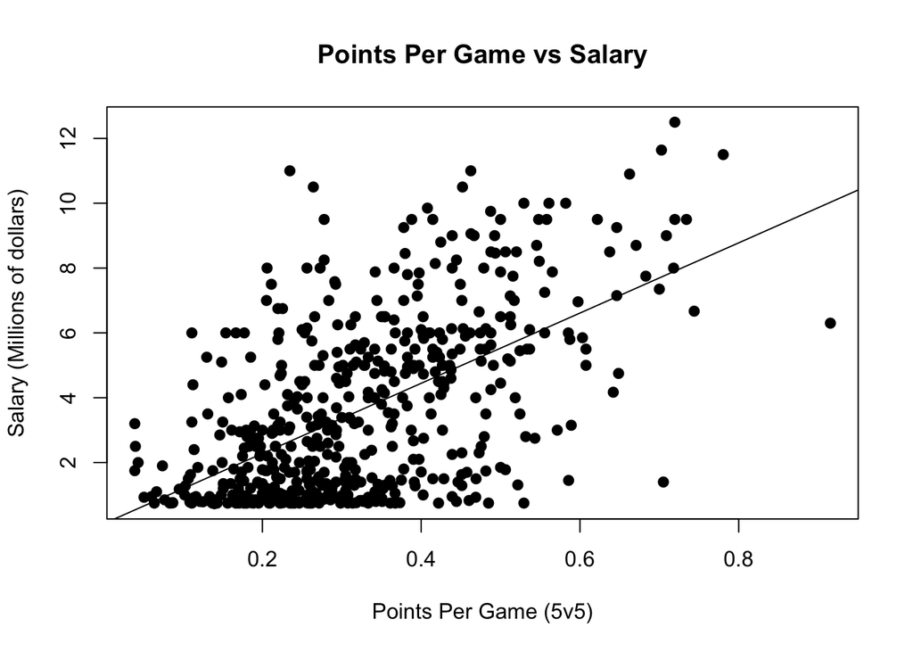

```r
model <- lm(Salary / 1e6 ~ PPG, data = all_data_filtered)
plot(all_data_filtered$PPG, all_data_filtered$Salary / 1e6, pch = 19, xlab = "Points Per Game (5v5)", ylab = "Salary (Millions of dollars)", main = "Points Per Game vs Salary")
abline(model, col = "black")
```

Creating a subset of data for a correlation plot

```r
library(dplyr)
subset <- all_data_filtered %>%
  ungroup() %>%
  select(Salary, TOIpg, Overall.Draft.Position, PPG, Offense_defense, Years_since_draft)
```

Creating the correlation plot

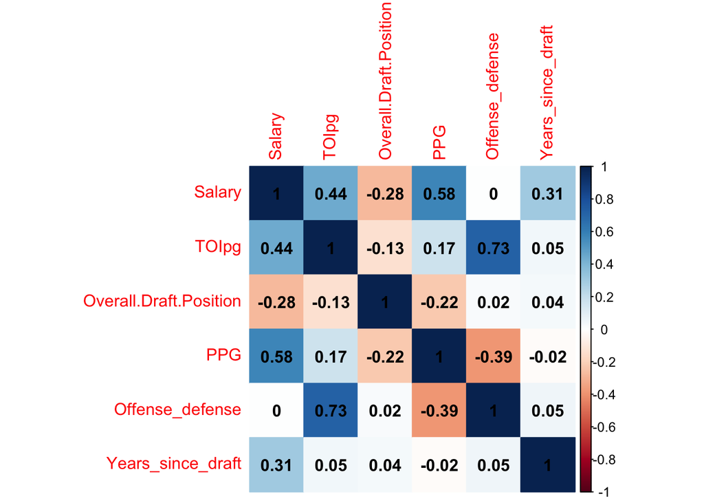

```r
library(corrplot)
subset2 <- data.frame(lapply(subset, as.numeric))
#Transforming Draft Position to a numeric value before creating the model
all_data_filtered$Overall.Draft.Position <- as.numeric(all_data_filtered$Overall.Draft.Position)
# Calculate the correlation matrix
correlation_matrix = cor(subset2)
corrplot(correlation_matrix, method = "color", addCoef.col = "black")
```

Creating a multiple regression model for our hypothesized significant variables

```r
hypothesized_best_model <- lm(Log_salary ~ TOIpg + Overall.Draft.Position + PPG + Offense_defense + Years_since_draft, data = all_data_filtered)
summary(hypothesized_best_model)
```

```
##
## Call:
## lm(formula = Log_salary ~ TOIpg + Overall.Draft.Position + PPG +
##     Offense_defense + Years_since_draft, data = all_data_filtered)
##
## Residuals:
##     Min      1Q  Median      3Q     Max
## -1.7840 -0.3461  0.0587  0.3825  1.1882
##
## Coefficients:
##                          Estimate Std. Error t value Pr(>|t|)
## (Intercept)            11.0346950  0.1890314  58.375  < 2e-16 ***
## TOIpg                   0.2233585  0.0184569  12.102  < 2e-16 ***
## Overall.Draft.Position -0.0018245  0.0004562  -3.999 7.26e-05 ***
## PPG                     1.4375815  0.2508653   5.730 1.68e-08 ***
## Offense_defense        -0.7037527  0.1088269  -6.467 2.27e-10 ***
## Years_since_draft       0.0646090  0.0056914  11.352  < 2e-16 ***
## ---
## Signif. codes:  0 '***' 0.001 '**' 0.01 '*' 0.05 '.' 0.1 ' ' 1
##
## Residual standard error: 0.5386 on 532 degrees of freedom
## Multiple R-squared:  0.5883, Adjusted R-squared:  0.5844
## F-statistic:   152 on 5 and 532 DF,  p-value: < 2.2e-16
```

```r
#First I will need to create a subset of the data frame
full_predictors <- all_data_filtered[c(
  "Log_salary", "CF.", "FF.", "SF.", "xGF.", "SCF.", "PDO", "Draft.Round",
  "Overall.Draft.Position", "IPP", "Shots", "Rush.Attempts", "Rebounds.Created", "PIM",
  "Penalties.Drawn", "Giveaways", "Takeaways", "Hits", "Shots.Blocked", "GPG", "TOIpg",
  "AsPG", "Years_since_draft", "Offense_defense", "GF.", "HDGF.", "MDGF.", "LDGF.", "PPG"
)]

#Making the entire df numeric
library(dplyr)

full_predictors <- full_predictors %>%
  mutate_all(as.numeric)
```

```r
require(MASS)
```

```r
min_model = lm(Log_salary ~ 1, data = full_predictors)
max_model = lm(Log_salary ~ CF. + FF. + SF. + xGF. + SCF. + PDO + Draft.Round + Overall.Draft.Position + IPP + Shots + Rush.Attempts + Rebounds.Created + PIM + Penalties.Drawn + Giveaways + Takeaways + Hits + Shots.Blocked + GPG + TOIpg + AsPG + Years_since_draft + Offense_defense + GF. + HDGF. + MDGF. + LDGF. + PPG, data = full_predictors)

best_model = step(min_model, scope = formula(max_model), direction = "both", k = log(538))
```

```
## Start:  AIC=-188.12
## Log_salary ~ 1
##
##                          Df Sum of Sq    RSS     AIC
## + AsPG                    1   120.681 254.17 -390.86
## + Shots                   1   114.319 260.53 -377.56
## + PPG                     1   108.617 266.23 -365.91
## + Giveaways               1    92.030 282.82 -333.39
## + TOIpg                   1    86.940 287.91 -323.79
## + Takeaways               1    85.768 289.08 -321.61
## + Rebounds.Created        1    69.274 305.57 -291.76
## + Years_since_draft       1    38.166 336.68 -239.60
## + GPG                     1    37.495 337.35 -238.53
## + SCF.                    1    28.314 346.53 -224.08
## + CF.                     1    26.698 348.15 -221.58
## + Overall.Draft.Position  1    25.195 349.65 -219.26
## + FF.                     1    22.224 352.62 -214.71
## + SF.                     1    20.425 354.42 -211.97
## + Draft.Round             1    18.676 356.17 -209.32
## + GF.                     1    17.922 356.92 -208.19
## + xGF.                    1    17.354 357.49 -207.33
## + Rush.Attempts           1    17.198 357.65 -207.10
## + MDGF.                   1    16.255 358.59 -205.68
## + Penalties.Drawn         1    13.686 361.16 -201.84
## + Shots.Blocked           1     8.552 366.29 -194.24
## + IPP                     1     7.021 367.83 -192.00
## + Hits                    1     6.878 367.97 -191.79
## + PDO                     1     5.387 369.46 -189.62
## + LDGF.                   1     5.303 369.54 -189.49
## + HDGF.                   1     4.864 369.98 -188.85
## <none>                                374.85 -188.12
## + Offense_defense         1     0.291 374.56 -182.24
## + PIM                     1     0.221 374.62 -182.14
##
## Step:  AIC=-390.86
## Log_salary ~ AsPG
##
##                          Df Sum of Sq    RSS     AIC
## + Years_since_draft       1    37.429 216.74 -470.28
## + Shots                   1    33.672 220.49 -461.03
```

[output cut: 218 more lines]

```
## + xGF.                    1     0.053 143.35 -654.95
## + IPP                     1     0.052 143.35 -654.95
## + SF.                     1     0.015 143.39 -654.81
## + FF.                     1     0.011 143.39 -654.80
## + CF.                     1     0.005 143.40 -654.78
## + Takeaways               1     0.001 143.40 -654.76
## + SCF.                    1     0.000 143.40 -654.76
## + MDGF.                   1     0.000 143.40 -654.76
## - Draft.Round             1     3.736 147.14 -653.50
## - Shots                   1     4.820 148.22 -649.55
## - Overall.Draft.Position  1     5.088 148.49 -648.57
## - AsPG                    1     8.589 151.99 -636.04
## - Offense_defense         1    12.151 155.55 -623.57
## - TOIpg                   1    27.607 171.01 -572.61
## - Years_since_draft       1    34.359 177.76 -551.78
```

Summary Statistics and ANOVA table of the best model

```r
best_BIC_model = lm(Log_salary ~ AsPG + Years_since_draft + Shots + TOIpg + Offense_defense +
    Overall.Draft.Position + Draft.Round, data = full_predictors)

summary(best_BIC_model)
```

```
##
## Call:
## lm(formula = Log_salary ~ AsPG + Years_since_draft + Shots +
##     TOIpg + Offense_defense + Overall.Draft.Position + Draft.Round,
##     data = full_predictors)
##
## Residuals:
##      Min       1Q   Median       3Q      Max
## -1.80969 -0.33085  0.05368  0.40409  1.15455
##
## Coefficients:
##                          Estimate Std. Error t value Pr(>|t|)
## (Intercept)            11.1148798  0.1882572  59.041  < 2e-16 ***
## AsPG                    1.8614540  0.3303907   5.634 2.86e-08 ***
## Years_since_draft       0.0621244  0.0055129  11.269  < 2e-16 ***
## Shots                   0.0031676  0.0007505   4.221 2.87e-05 ***
## TOIpg                   0.1879796  0.0186097  10.101  < 2e-16 ***
## Offense_defense        -0.6486806  0.0967979  -6.701 5.29e-11 ***
## Overall.Draft.Position -0.0110490  0.0025478  -4.337 1.73e-05 ***
## Draft.Round             0.2941449  0.0791619   3.716 0.000224 ***
## ---
## Signif. codes:  0 '***' 0.001 '**' 0.01 '*' 0.05 '.' 0.1 ' ' 1
##
## Residual standard error: 0.5202 on 530 degrees of freedom
## Multiple R-squared:  0.6174, Adjusted R-squared:  0.6124
## F-statistic: 122.2 on 7 and 530 DF,  p-value: < 2.2e-16
```

```r
anova(best_BIC_model)
```

```
## Analysis of Variance Table
##
## Response: Log_salary
##                         Df  Sum Sq Mean Sq F value    Pr(>F)
## AsPG                     1 120.681 120.681 446.025 < 2.2e-16 ***
## Years_since_draft        1  37.429  37.429 138.336 < 2.2e-16 ***
## Shots                    1  29.746  29.746 109.937 < 2.2e-16 ***
## TOIpg                    1  22.766  22.766  84.142 < 2.2e-16 ***
## Offense_defense          1  12.943  12.943  47.834  1.34e-11 ***
## Overall.Draft.Position   1   4.143   4.143  15.314 0.0001029 ***
## Draft.Round              1   3.736   3.736  13.807 0.0002241 ***
## Residuals              530 143.402   0.271
## ---
## Signif. codes:  0 '***' 0.001 '**' 0.01 '*' 0.05 '.' 0.1 ' ' 1
```

Plotting the hypothesized and best BIC model residuals

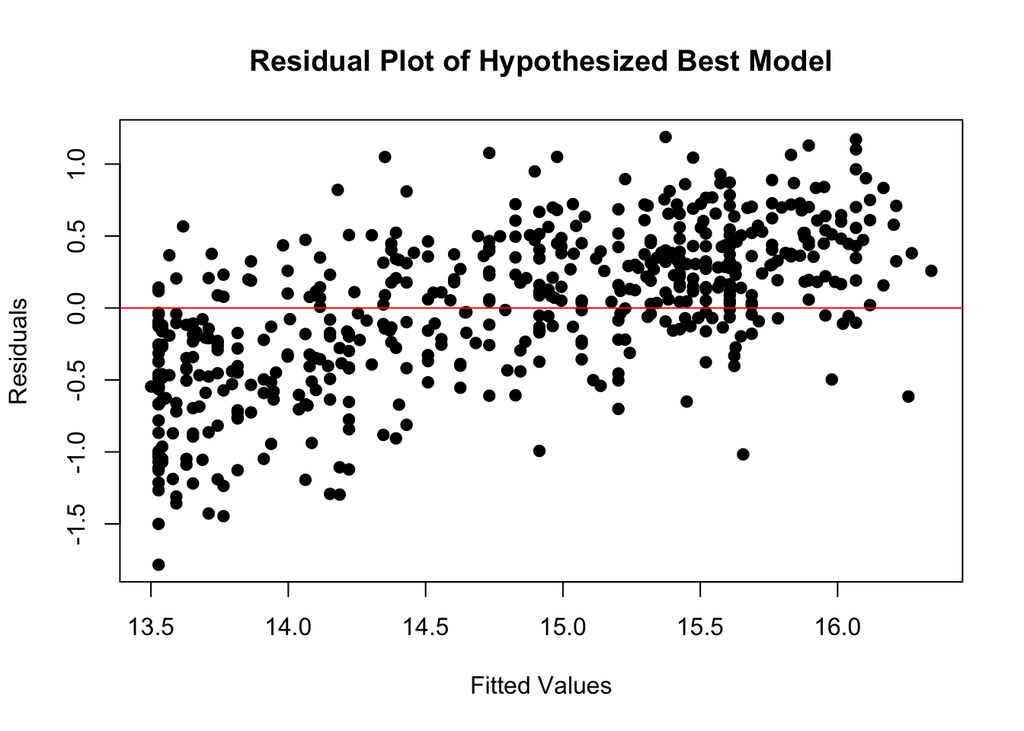

```r
plot(full_predictors$Log_salary, residuals(hypothesized_best_model), pch =19, main = "Residual Plot of Hypothesized Best Model", xlab ="Fitted Values", ylab = "Residuals")
abline(h=0,col="red")
```

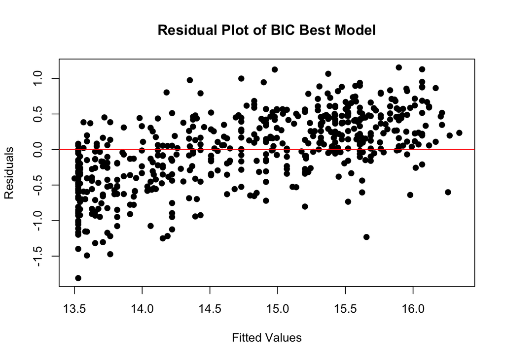

```r
plot(full_predictors$Log_salary, residuals(best_BIC_model), pch =19, main = "Residual Plot of BIC Best Model", xlab ="Fitted Values", ylab = "Residuals")
abline(h=0,col="red")
```

Running the full model

```r
full_model = lm(Log_salary ~ PPG + CF. + FF. + SF. + xGF. + SCF. + PDO + Draft.Round + Overall.Draft.Position + IPP + Shots + Rush.Attempts + Rebounds.Created + PIM + Penalties.Drawn + Giveaways + Takeaways + Hits + Shots.Blocked + GPG + TOIpg + Years_since_draft + Offense_defense + GF. + HDGF. + MDGF. + LDGF., data = full_predictors)
summary(full_model)
```

```
##
## Call:
## lm(formula = Log_salary ~ PPG + CF. + FF. + SF. + xGF. + SCF. +
##     PDO + Draft.Round + Overall.Draft.Position + IPP + Shots +
##     Rush.Attempts + Rebounds.Created + PIM + Penalties.Drawn +
##     Giveaways + Takeaways + Hits + Shots.Blocked + GPG + TOIpg +
##     Years_since_draft + Offense_defense + GF. + HDGF. + MDGF. +
##     LDGF., data = full_predictors)
##
## Residuals:
##     Min      1Q  Median      3Q     Max
## -1.8498 -0.3175  0.0511  0.3842  1.2125
##
## Coefficients:
##                          Estimate Std. Error t value Pr(>|t|)
## (Intercept)            19.1960736  8.0710044   2.378 0.017755 *
## PPG                     2.1626549  0.5118167   4.225 2.83e-05 ***
## CF.                    -0.0480720  0.0330589  -1.454 0.146525
## FF.                     0.0452693  0.0397783   1.138 0.255639
## SF.                    -0.0246659  0.0359223  -0.687 0.492619
## xGF.                   -0.0157515  0.0179546  -0.877 0.380740
## SCF.                    0.0253065  0.0193030   1.311 0.190443
## PDO                    -7.6952564  8.0129418  -0.960 0.337332
## Draft.Round             0.2788991  0.0803055   3.473 0.000558 ***
## Overall.Draft.Position -0.0103793  0.0025870  -4.012 6.92e-05 ***
## IPP                    -0.0027764  0.0032821  -0.846 0.398002
## Shots                   0.0042071  0.0012495   3.367 0.000817 ***
## Rush.Attempts          -0.0052881  0.0039461  -1.340 0.180816
## Rebounds.Created       -0.0026353  0.0051311  -0.514 0.607763
## PIM                    -0.0004852  0.0015147  -0.320 0.748847
## Penalties.Drawn        -0.0021967  0.0047550  -0.462 0.644289
## Giveaways               0.0039110  0.0024618   1.589 0.112750
## Takeaways              -0.0010196  0.0026029  -0.392 0.695442
## Hits                   -0.0006090  0.0005481  -1.111 0.267034
## Shots.Blocked          -0.0004256  0.0015566  -0.273 0.784646
## GPG                    -2.2346904  0.5906065  -3.784 0.000173 ***
## TOIpg                   0.1726732  0.0231585   7.456 3.85e-13 ***
## Years_since_draft       0.0631072  0.0057030  11.066  < 2e-16 ***
## Offense_defense        -0.7079339  0.1438934  -4.920 1.17e-06 ***
## GF.                     0.0297098  0.0357962   0.830 0.406943
## HDGF.                  -0.0092486  0.0115856  -0.798 0.425077
## MDGF.                  -0.0029591  0.0064721  -0.457 0.647710
## LDGF.                  -0.0007670  0.0029895  -0.257 0.797620
## ---
## Signif. codes:  0 '***' 0.001 '**' 0.01 '*' 0.05 '.' 0.1 ' ' 1
##
## Residual standard error: 0.5218 on 510 degrees of freedom
## Multiple R-squared:  0.6295, Adjusted R-squared:  0.6099
## F-statistic:  32.1 on 27 and 510 DF,  p-value: < 2.2e-16
```